# CHNS – Longitudinal Example

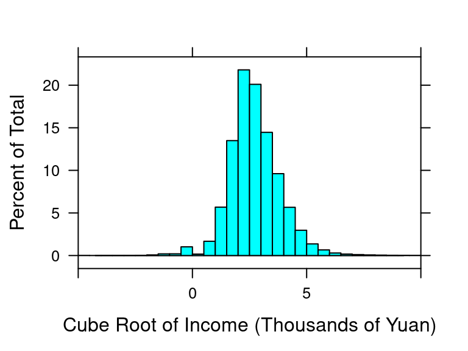

```r
histogram(sign(sashhinc$thousands) * abs(sashhinc$thousands)^(1/3), breaks = 50,
          xlim=c(-5, 10),xlab = "Cube Root of Income (Thousands of Yuan)")
```

We then want to see how income evolves over time and look at household trajectories.It is quite hard to actually see the different households as there are so many. However, we see that the trend over time is positive meaning that real income per capita increases and household are getting richer overall.

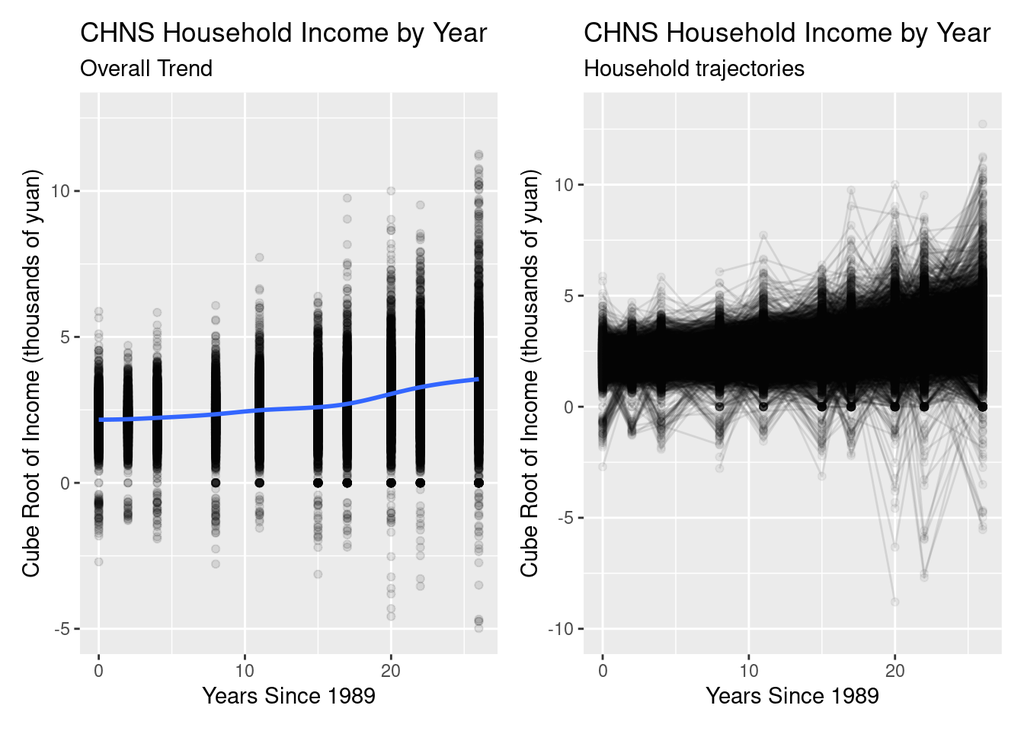

```r
sashhinc <- sashhinc %>% mutate(
    thousands_croot = sign(thousands) * abs(thousands)^(1/3))

p1 <- ggplot(data=sashhinc, aes(cyear, thousands_croot)) +
        geom_point(alpha=.1) +
        ylim(-5,12.5) +
        geom_smooth() +
        xlab("Years Since 1989") +
        ylab("Cube Root of Income (thousands of yuan)") +
        ggtitle("CHNS Household Income by Year",
                "Overall Trend")

p2 <- ggplot(sashhinc, aes(x=cyear,y=thousands_croot,group=hhid)) +
        ylim(-10,13) +
        geom_point(alpha=0.05) + geom_line(alpha=0.1) +
        #geom_abline(data=est, aes(intercept=int, slope=sl),col="red") +
        xlab("Years Since 1989") +
        ylab("Cube Root of Income (thousands of yuan)") +
        ggtitle("CHNS Household Income by Year",
                "Household trajectories")

p1 + p2
```

```r
fit.null=lmer(thousands_croot ~ (1|hhid), data=sashhinc)
fit.1=lmer(thousands_croot ~ cyear + (1|hhid), data=sashhinc)
anova(fit.null, fit.1)
```

```
## Data: sashhinc
## Models:
## fit.null: thousands_croot ~ (1 | hhid)
## fit.1: thousands_croot ~ cyear + (1 | hhid)
##          npar    AIC    BIC logLik deviance  Chisq Df Pr(>Chisq)
## fit.null    3 128498 128524 -64246   128492
## fit.1       4 120747 120782 -60369   120739 7752.8  1  < 2.2e-16 ***
## ---
## Signif. codes:  0 '***' 0.001 '**' 0.01 '*' 0.05 '.' 0.1 ' ' 1
```

Including a linear term for time actually improves the model. We would also like to know if the trend differs by household and so we try to fit a random slope.

```r
fit.2=lmer(thousands_croot~cyear + (1+cyear|hhid),data = sashhinc)
```

```
## boundary (singular) fit: see ?isSingular
```

What is the “singular” warning. It is due to the fact that we only have one observation for some households. As a result, we cannot estimate any slope for these households.  
We could also test for the linearity of the relationship between income and WAVE by fitting polynomials.

```r
fit.3 = lmer(thousands_croot ~ poly(cyear, 2) + (1|hhid), data = sashhinc)
fit.4 = lmer(thousands_croot ~ poly(cyear, 3) + (1|hhid), data = sashhinc)
anova(fit.1, fit.3, fit.4)
```

```
## Data: sashhinc
## Models:
## fit.1: thousands_croot ~ cyear + (1 | hhid)
## fit.3: thousands_croot ~ poly(cyear, 2) + (1 | hhid)
## fit.4: thousands_croot ~ poly(cyear, 3) + (1 | hhid)
##       npar    AIC    BIC logLik deviance    Chisq Df Pr(>Chisq)
## fit.1    4 120747 120782 -60369   120739
## fit.3    5 120043 120086 -60016   120033 706.2832  1     <2e-16 ***
## fit.4    6 120044 120096 -60016   120032   1.1072  1     0.2927
## ---
## Signif. codes:  0 '***' 0.001 '**' 0.01 '*' 0.05 '.' 0.1 ' ' 1
```

A second degree polynomial might be appropriate. However, in order to keep the example simple, we will proceed assuming a linear relationship between time and income per capita.

When looking at the diagnostics plot, the residuals do not follow the normal distribution. The residual Vs. fitted plot has a funnel shape indicating heteroskedasticity.

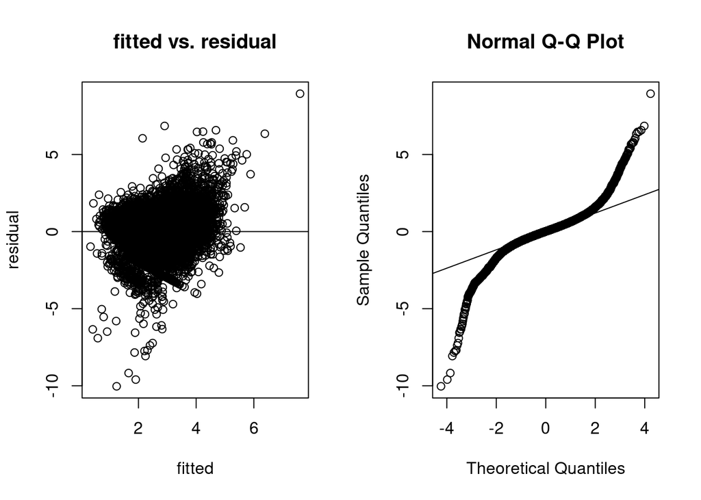

```r
par(mfrow=c(1,2))
plot(fitted(fit.1), resid(fit.1), xlab = 'fitted', ylab='residual', main='fitted vs. residual')
abline(h=0)
qqnorm(resid(fit.1))
qqline(resid(fit.1))
```

Despite these bad diagnostics, we can still interpret the results.

```r
sum1 <- summary(fit.1)
knitr::kable(sum1$coefficients, caption = "Summary of the original model")
```

Summary of the original model

|  | Estimate | Std. Error | t value |
| --- | --- | --- | --- |
| (Intercept) | 2.0784686 | 0.0113424 | 183.24817 |
| cyear | 0.0507348 | 0.0005497 | 92.29159 |